# DATA 698 Final Presentation

Josh Iden

# Measuring “Star Power”: Predicting Movie Box Office Revenue Based on Directors’ and Leading Actors’ Recent Success

# Film Industry Statistics

- 42.5B USD to the US Economy (as of 2022)
- 2.5 million jobs (Zane, 2023)
- 36% of movies make profit (Lash, Zhao, 2016)
- Avg. tenure of executives:
  - 1940s: 20 years
  - 1980s: 4 (Ravid, 1999)

# Literature Review

- Linear Regression using Rentals as response
- Economic Theory vs. Communication Theory
- Static factors vs. Dynamic factors
- Neural Nets, Random Forest
- International Films

# “Star Power”

- Binary variables or Rankings
- IMDb popularity
- Cumulative lifetime earnings
- Classification modeling
- Full cast

# Hypothesis and Methodology

- Tree-based models
- Continuous and Categorical
- Ensemble models
  - Bagged Trees, Random Forest, XGBoost, Cubist
  - High accuracy and generalizability
- Hypothesis: Star Power is an important predictor of revenue
- Variable Importance Measures
  - Top 5 Variables
- Mean Absolute Percentage Error (MAPE)
  - MAPE below 5%

## Data Acquisition

- Written and cleaned in Python
- Web Scraping: IMDb, Box Office Mojo
- API: OMBb

## Data Acquisition

- Box Office Mojo
  - Unique IMDB IDs for the Top 200 earning movies per year
- IMDb
  - Production budgets
  - Leading actor and Director Unique IDs
- OMDb
  - Must be queried by unique IMDB IDs
  - Title, Year, Rating, Release Date, Runtime, Genre, Director, Writer, Actors, Plot, Language, Country, Awards, Poster, MetaRating, Domestic Box Office Revenue

## Combined Dataset

[figure not shown]

# Feature Engineering

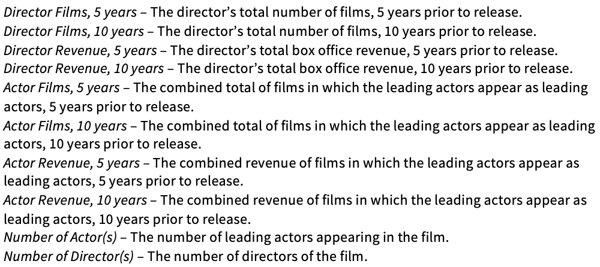

## Feature Engineering

- R
- Subset data to 2012-2022 to have full 10 year data beginning in 2012
- Combine low frequency values
  - Country: United States vs. Foreign
  - Language: English vs. Foreign
  - Genres
  - Rating

# Exploratory Data Analysis

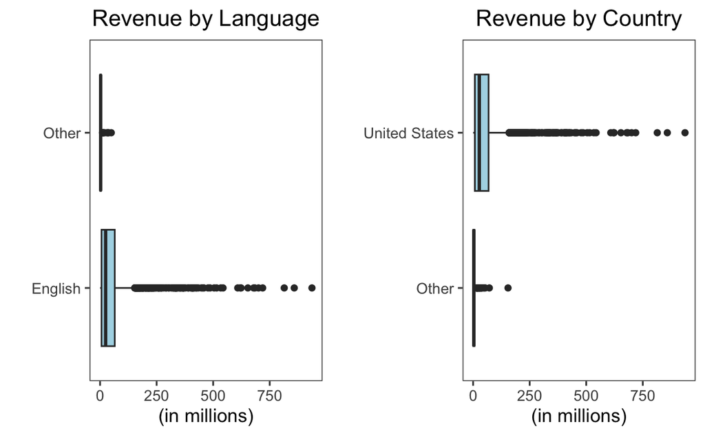

## Exploratory Data Analysis

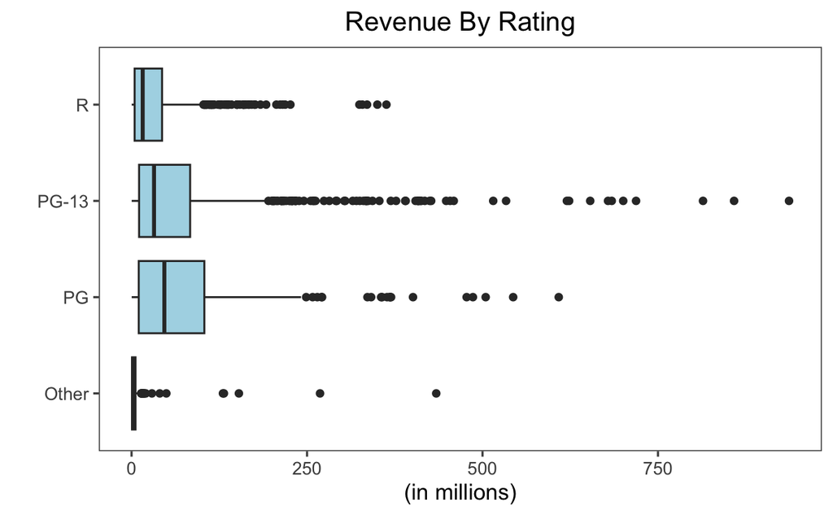

## Exploratory Data Analysis

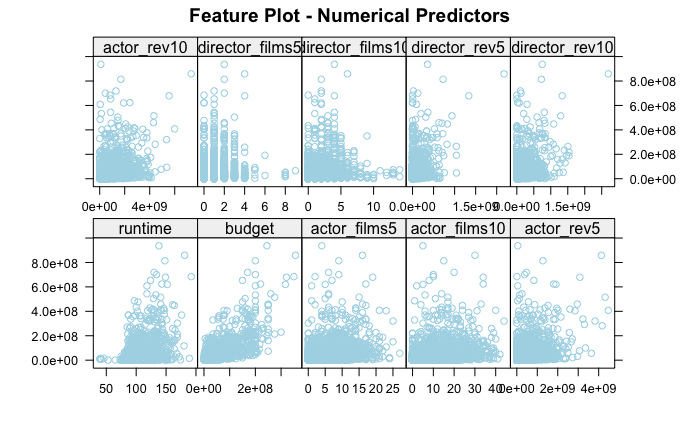

## Exploratory Data Analysis

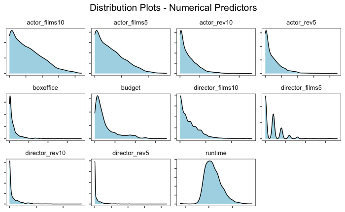

.

## Exploratory Data Analysis

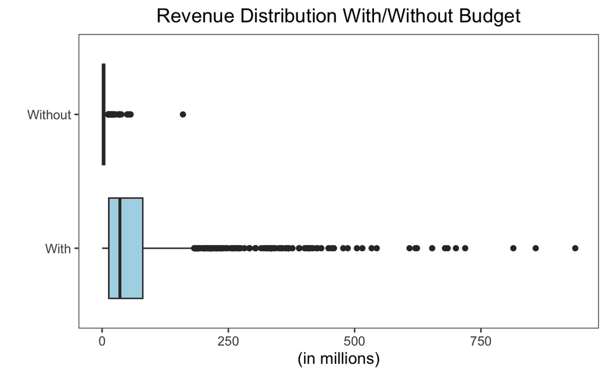

## Summary Statistics

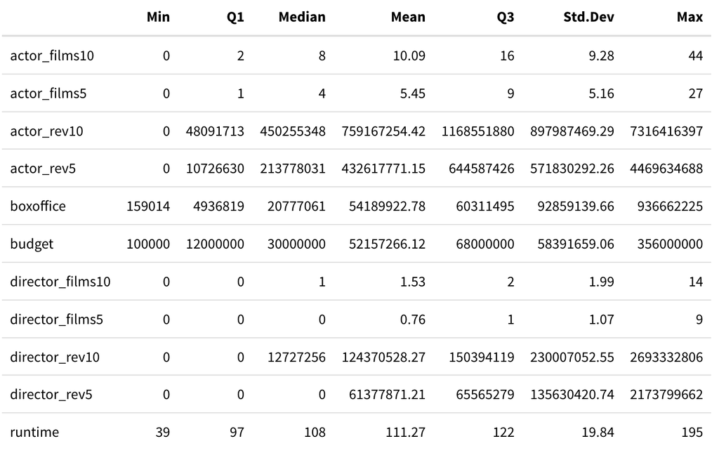

# Model Prep

- Handling missing values
- Transforming the response
- Feature scaling

## Handling Missing Values

- Approaches
  - Drop observations
  - 5- nearest neighbors imputation
  - Zero imputation and categorical budget variable (Y/N)
  - Transform budget into categorical by IQR
- Best results: zero imputation + categorical variable

## Transforming the Response

- Highly right-skewed
- Box-Cox transformation

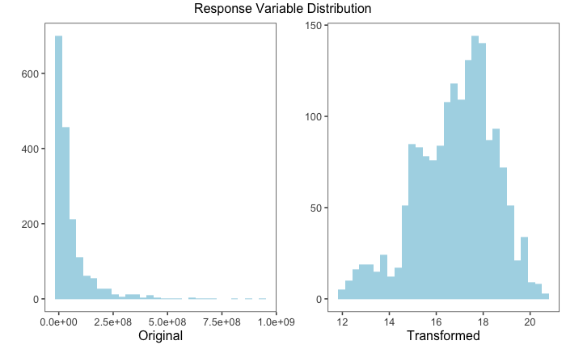

## Feature Scaling

- Reduces the standard deviation to 1
- Improves model performance
- No centering performed

# Modeling

- Caret Package in R
- Model Versions
- Hyperparameter Tuning
- Variable Importance
- Findings

## Model Versions

- Shuffle & 80/20 Split
- 10-fold Cross-Validation
- Five “Focus” Models

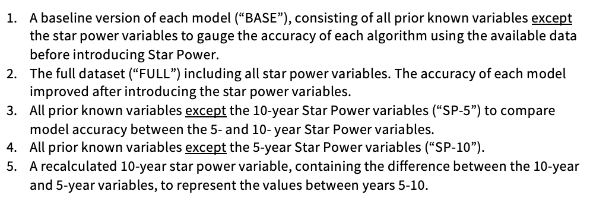

## Hyperparameter Tuning

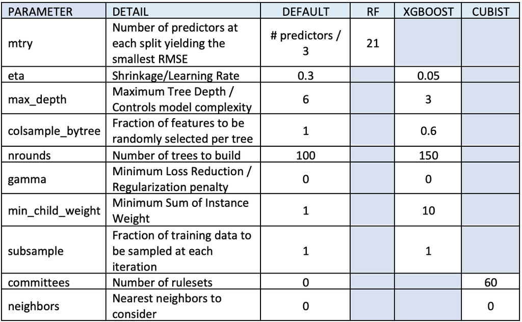

## Variable Importance

- Bagged Trees & Random Forest:
  - Avg. Decrease in MSE when a predictor is excluded.
- XGBoost:
  - Number of timese a variable is used to split the data.
- Cubist:
  - Linear combination of the percentage of times each variable is used.

## Variable Importance

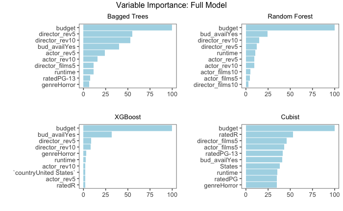

## Findings

- Results by MAPE

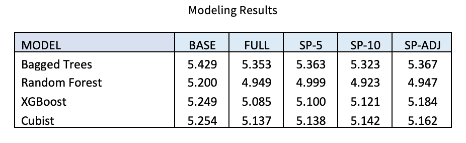

## Findings

- Variable Importance - Best Model

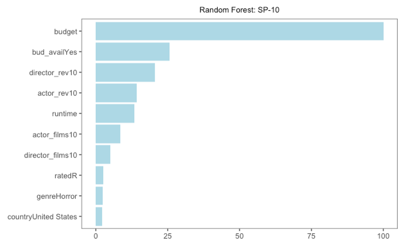